# Quarto Example

Author

Jim Urick

## Markdown, R Markdown, Quarto

Markdown is a markup language. Find a cheat sheet [like this one](https://www.markdownguide.org/cheat-sheet/) to learn the syntax for things like

You can render notebooks (with the “Render” button) to a variety of formats, like PDF, HTML, slides or plain Markdown. The header here is set up to render to a standalone HTML file.

[R Markdown](https://rmarkdown.rstudio.com/) adds some more functionality to plain Markdown, like code chunks

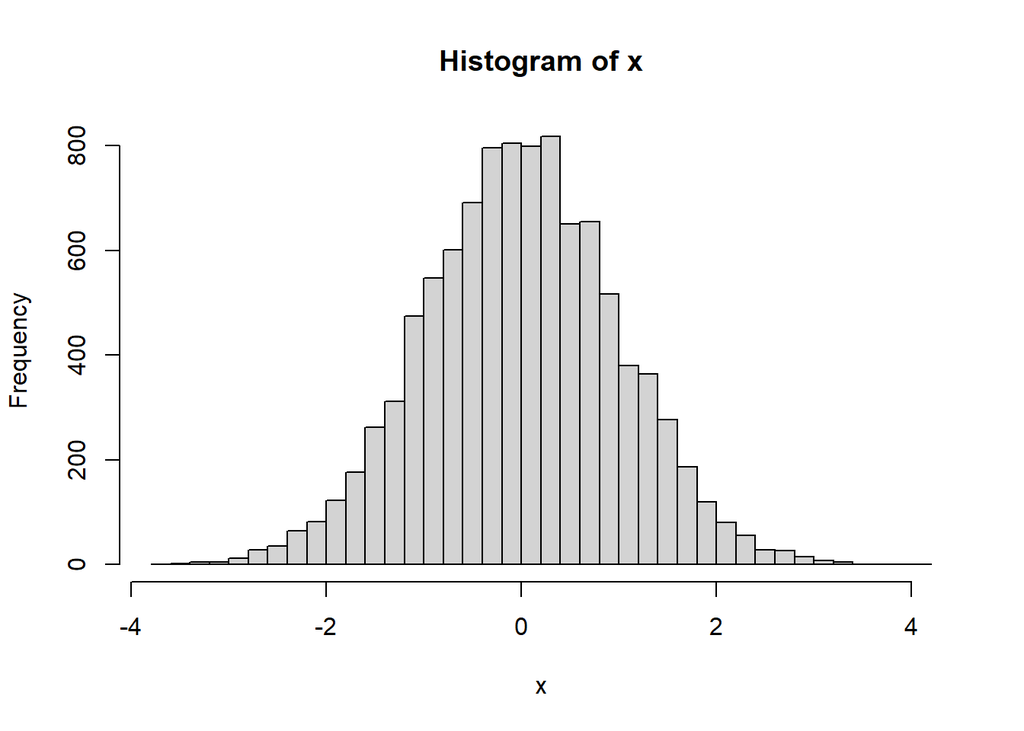

```r
x <- rnorm(10000)
hist(x, 50)
```

[Quarto](https://quarto.org/) is a newer version of R Markdown made by [Posit](https://posit.co/) (formerly named RStudio). Older notebook files may have an “.rmd” extension for R Markdown, while newer “.qmd” files are Quarto.

Quarto adds some fancier things like [tabset panels](https://quarto.org/docs/interactive/layout.html#tabset-panel):

**Normal Distribution**

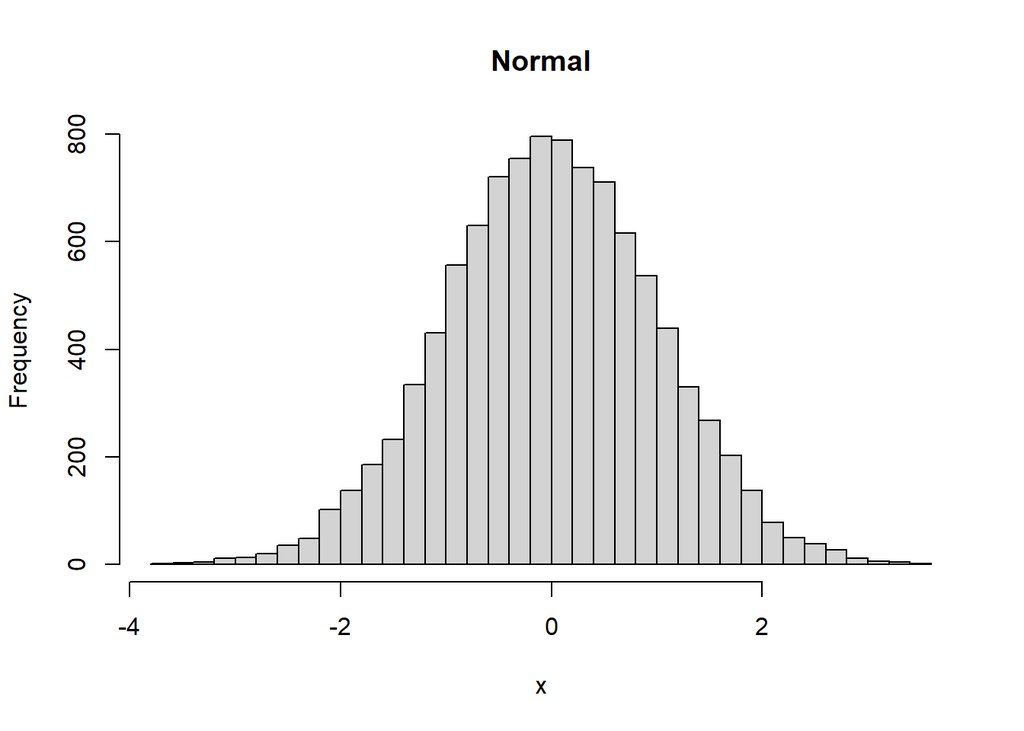

```r
x <- rnorm(10000)
hist(x, 50, main = "Normal")
```

**\(\Gamma\) Distribution**

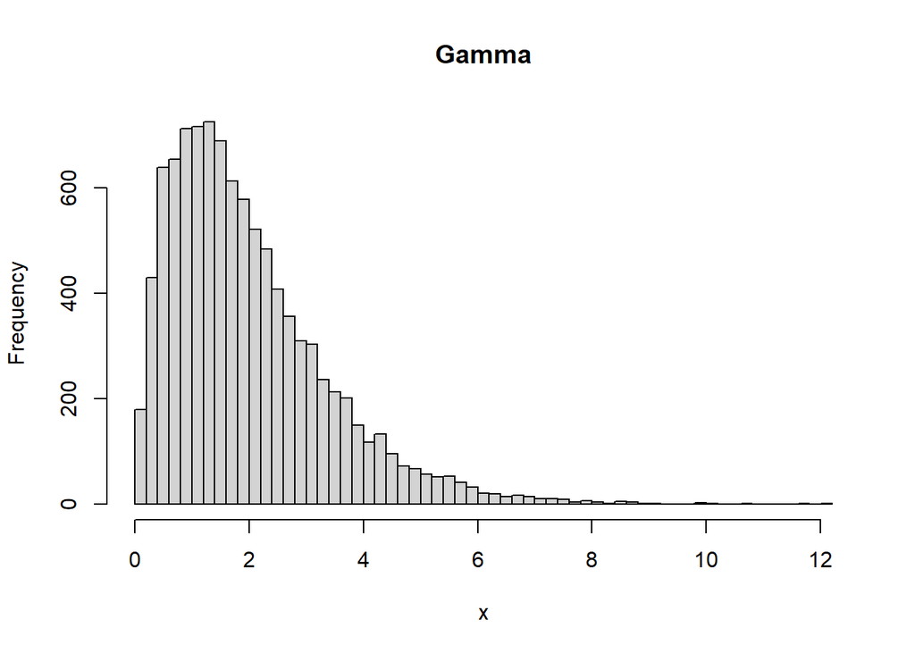

```r
x <- rgamma(10000, shape = 2)
hist(x, 50, main = "Gamma")
```

## LaTeX with MathJax

MathJax is a Javascript engine that renders $\LaTeX$ in R Markdown. It doesn’t do everything that $\LaTeX$ does, but it does enough for most purposes. Find some cheat sheets like [this one](https://quickref.me/latex.html) or [this one](https://wch.github.io/latexsheet/latexsheet.pdf) to learn how to do basics.

You can include inline math with a single `$`, like $e^{\pi i}$, or you can use `$$` for “display” math:

$$\frac{d}{dx}\int_{a}^{x}f(t)\,dt=f(x)$$

You can show multiple lines of work with the `align` environment.

Use `pmatrix` to create matrices with parentheses. For example, if $f_n$ is the $n^{\textsf{th}}$ Fibonacci number, note that

$$\begin{pmatrix} 1 & 1 \\ 1 & 0 \end{pmatrix}
\begin{pmatrix} f_{n} \\ f_{n-1} \end{pmatrix}
=\begin{pmatrix} f_{n+1} \\ f_{n} \end{pmatrix}.$$

Let $\phi_{\pm}=\tfrac12(1\pm\sqrt5)$ and diagonalize that matrix to show that

## Macros

You can also use some $\TeX$ macros like `\def\eps{\varepsilon}` in case you want a shortcut for $\varepsilon$ but don’t want to overwrite `\epsilon`=$\epsilon$. That can be a little odd in a notebook because that code doesn’t render to anything: $\def\eps{\varepsilon}$.

It’s often better to use javascript, like the file “latex.js” in this directory, which is included in the header (see the [notes](https://jimurick.github.io/vermont/notes/quarto/quarto.html#header)). That file is described in the [MathJax documentation](https://docs.mathjax.org/en/latest/input/tex/macros.html). I used it to define `\R`=$\R$ to be `\mathbb{R}`.

## Two `tidyverse` Packages

If you’re interested in working with data in R, it’s a good idea to read Hadley Wickham’s [R for Data Science](https://r4ds.hadley.nz/). The metapackage `tidyverse` includes most of the packages described there.

```r
library(tidyverse)
```

Two of the main packages are

- [`ggplot2`](https://ggplot2-book.org/), based on the book The Grammar of Graphics, and
- [`dplyr`](https://dplyr.tidyverse.org/), “a grammar for data manipulation”.

To get practice, it can help to know that R loads some dataset like `mtcars` from the `datasets` package.

```r
head(mtcars)
```

```
                   mpg cyl disp  hp drat    wt  qsec vs am gear carb
Mazda RX4         21.0   6  160 110 3.90 2.620 16.46  0  1    4    4
Mazda RX4 Wag     21.0   6  160 110 3.90 2.875 17.02  0  1    4    4
Datsun 710        22.8   4  108  93 3.85 2.320 18.61  1  1    4    1
Hornet 4 Drive    21.4   6  258 110 3.08 3.215 19.44  1  0    3    1
Hornet Sportabout 18.7   8  360 175 3.15 3.440 17.02  0  0    3    2
Valiant           18.1   6  225 105 2.76 3.460 20.22  1  0    3    1
```

You should also get used to the [pipe operator](https://ggplot2-book.org/) `|>`. It’s two characters, a vertical line `|` and greater than `>`, but the Fira Code font combines them into something like $\LaTeX$’s `\triangleright` ($\triangleright$).

```r
# equivalent to head(mtcars)
mtcars |> head()
```

```
                   mpg cyl disp  hp drat    wt  qsec vs am gear carb
Mazda RX4         21.0   6  160 110 3.90 2.620 16.46  0  1    4    4
Mazda RX4 Wag     21.0   6  160 110 3.90 2.875 17.02  0  1    4    4
Datsun 710        22.8   4  108  93 3.85 2.320 18.61  1  1    4    1
Hornet 4 Drive    21.4   6  258 110 3.08 3.215 19.44  1  0    3    1
Hornet Sportabout 18.7   8  360 175 3.15 3.440 17.02  0  0    3    2
Valiant           18.1   6  225 105 2.76 3.460 20.22  1  0    3    1
```

```r
mtcars |>
  select(mpg, disp) |>
  mutate(nonsense = mpg + disp) |>
  head()
```

```
                   mpg disp nonsense
Mazda RX4         21.0  160    181.0
Mazda RX4 Wag     21.0  160    181.0
Datsun 710        22.8  108    130.8
Hornet 4 Drive    21.4  258    279.4
Hornet Sportabout 18.7  360    378.7
Valiant           18.1  225    243.1
```

```r
head(mutate(select(mtcars, mpg, disp), nonsense = mpg + disp))
```

```
                   mpg disp nonsense
Mazda RX4         21.0  160    181.0
Mazda RX4 Wag     21.0  160    181.0
Datsun 710        22.8  108    130.8
Hornet 4 Drive    21.4  258    279.4
Hornet Sportabout 18.7  360    378.7
Valiant           18.1  225    243.1
```

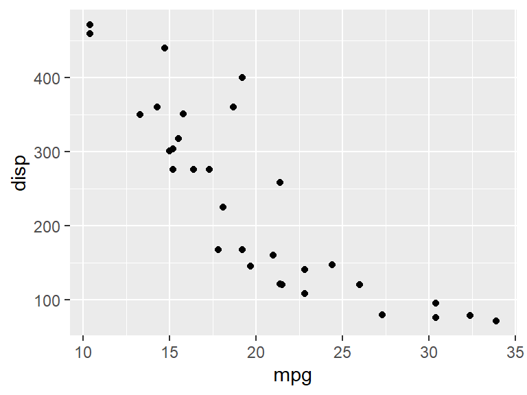

```r
mtcars |>
  ggplot(aes(mpg, disp)) +
  geom_point()
```

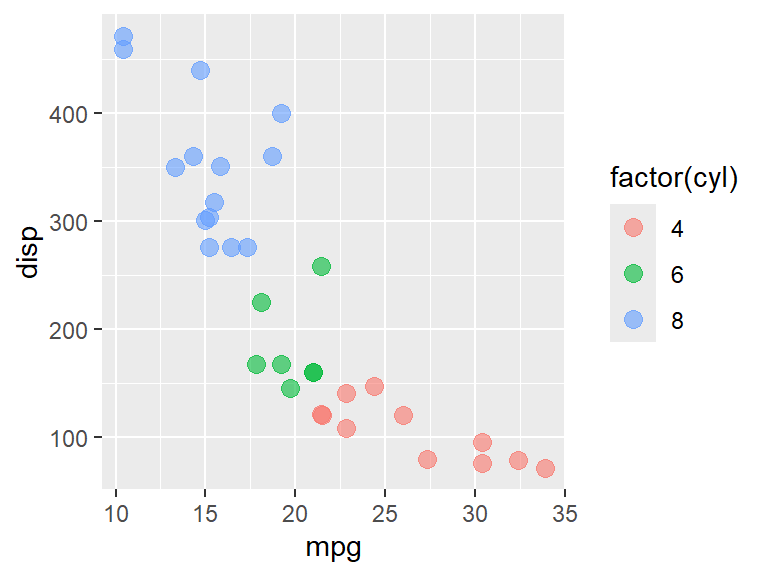

```r
mtcars |>
  ggplot(aes(mpg, disp, color = factor(cyl))) +
  geom_point(size = 3, alpha = 0.6)
```

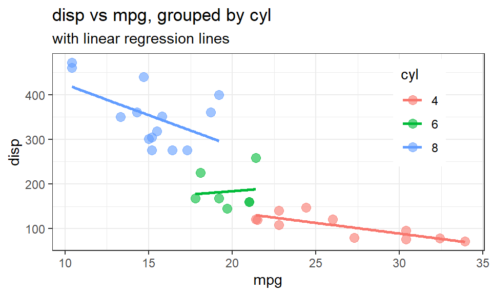

```r
mtcars |>
  mutate(cyl = factor(cyl)) |>
  ggplot(aes(mpg, disp, color = cyl, group = cyl)) +
  geom_point(size = 3, alpha = 0.6) +
  geom_smooth(method = 'lm', formula = y~x, se = FALSE) +
  theme_bw() +
  theme(legend.position = "inside", legend.position.inside = c(0.85, 0.7)) +
  ggtitle("disp vs mpg, grouped by cyl",
          subtitle = "with linear regression lines")
```